# TP2

2023-02-20

## Question 1

Lecture des données

```r
library(ggplot2)
prostateCancer <- read.table('./prostate.data.txt',header=TRUE)
prostateCancer <- prostateCancer[,colnames(prostateCancer) != "train"]
attach(prostateCancer)
dim(prostateCancer)
```

```
## [1] 97  9
```

```r
head(prostateCancer)
```

```
##       lcavol  lweight age      lbph svi       lcp gleason pgg45       lpsa
## 1 -0.5798185 2.769459  50 -1.386294   0 -1.386294       6     0 -0.4307829
## 2 -0.9942523 3.319626  58 -1.386294   0 -1.386294       6     0 -0.1625189
## 3 -0.5108256 2.691243  74 -1.386294   0 -1.386294       7    20 -0.1625189
## 4 -1.2039728 3.282789  58 -1.386294   0 -1.386294       6     0 -0.1625189
## 5  0.7514161 3.432373  62 -1.386294   0 -1.386294       6     0  0.3715636
## 6 -1.0498221 3.228826  50 -1.386294   0 -1.386294       6     0  0.7654678
```

```r
summary(prostateCancer)
```

```
##      lcavol           lweight           age             lbph
##  Min.   :-1.3471   Min.   :2.375   Min.   :41.00   Min.   :-1.3863
##  1st Qu.: 0.5128   1st Qu.:3.376   1st Qu.:60.00   1st Qu.:-1.3863
##  Median : 1.4469   Median :3.623   Median :65.00   Median : 0.3001
##  Mean   : 1.3500   Mean   :3.629   Mean   :63.87   Mean   : 0.1004
##  3rd Qu.: 2.1270   3rd Qu.:3.876   3rd Qu.:68.00   3rd Qu.: 1.5581
##  Max.   : 3.8210   Max.   :4.780   Max.   :79.00   Max.   : 2.3263
##       svi              lcp             gleason          pgg45
##  Min.   :0.0000   Min.   :-1.3863   Min.   :6.000   Min.   :  0.00
##  1st Qu.:0.0000   1st Qu.:-1.3863   1st Qu.:6.000   1st Qu.:  0.00
##  Median :0.0000   Median :-0.7985   Median :7.000   Median : 15.00
##  Mean   :0.2165   Mean   :-0.1794   Mean   :6.753   Mean   : 24.38
##  3rd Qu.:0.0000   3rd Qu.: 1.1787   3rd Qu.:7.000   3rd Qu.: 40.00
##  Max.   :1.0000   Max.   : 2.9042   Max.   :9.000   Max.   :100.00
##       lpsa
##  Min.   :-0.4308
##  1st Qu.: 1.7317
##  Median : 2.5915
##  Mean   : 2.4784
##  3rd Qu.: 3.0564
##  Max.   : 5.5829
```

## Question 2:

D’après la matrice de corrélation obtenue, on constate une forte corrélation entre lcavol et les deux prédicteurs lcp et lpsa, avec des coefficients de corrélations respectifs de 0,675 et 0,734. Les différents coefficients de corrélation sont également visualisables sur le graphe, accompagnés de droites de régression obtenues avec la méthode des moindres carrés ordinaires.

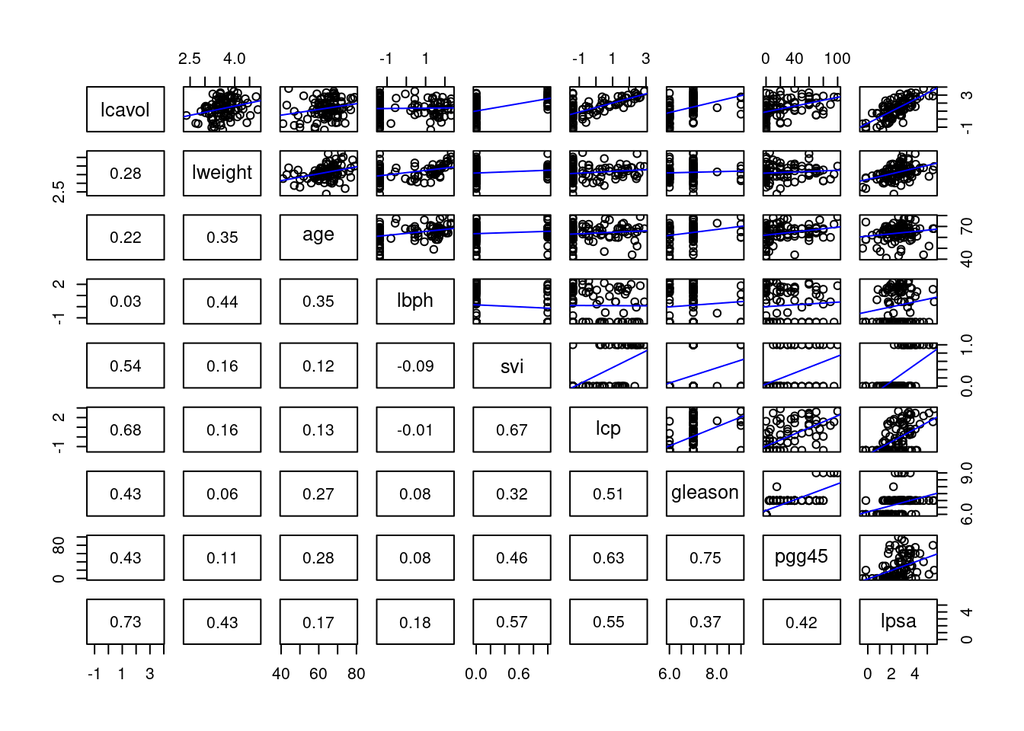

```r
droite_reg <- function(x,y) {
    points(x,y)
    abline(lsfit(x,y),col="blue")
}
correlation_valeur <- function(x,y){
  par(usr = c(0, 1, 0, 1))
  coeff <- round(cor(x,y),digits = 2)
  text(0.5,0.5,coeff)
}
pairs(prostateCancer,upper.panel = droite_reg,lower.panel = correlation_valeur)
```

```r
cor(prostateCancer)
```

```
##            lcavol    lweight       age         lbph         svi          lcp
## lcavol  1.0000000 0.28052138 0.2249999  0.027349703  0.53884500  0.675310484
## lweight 0.2805214 1.00000000 0.3479691  0.442264399  0.15538490  0.164537142
## age     0.2249999 0.34796911 1.0000000  0.350185896  0.11765804  0.127667752
## lbph    0.0273497 0.44226440 0.3501859  1.000000000 -0.08584324 -0.006999431
## svi     0.5388450 0.15538490 0.1176580 -0.085843238  1.00000000  0.673111185
## lcp     0.6753105 0.16453714 0.1276678 -0.006999431  0.67311118  1.000000000
## gleason 0.4324171 0.05688209 0.2688916  0.077820447  0.32041222  0.514830063
## pgg45   0.4336522 0.10735379 0.2761124  0.078460018  0.45764762  0.631528246
## lpsa    0.7344603 0.43331938 0.1695928  0.179809404  0.56621822  0.548813175
##            gleason      pgg45      lpsa
## lcavol  0.43241706 0.43365225 0.7344603
## lweight 0.05688209 0.10735379 0.4333194
## age     0.26889160 0.27611245 0.1695928
## lbph    0.07782045 0.07846002 0.1798094
## svi     0.32041222 0.45764762 0.5662182
## lcp     0.51483006 0.63152825 0.5488132
## gleason 1.00000000 0.75190451 0.3689868
## pgg45   0.75190451 1.00000000 0.4223159
## lpsa    0.36898681 0.42231586 1.0000000
```

## Question 3:

On s’intéresse à construire un modèle predictive pour la variable $lcavol$. On remarque premièrement qu’on a deux prédicteurs qualitatives svi et gleason, on utilise la fonction $factor()$ pour avoir des prédicteurs de niveaux pour chacun d’eux. Et on utilise l’équation de regression suivante:

$\text{lcavol} = \beta_{0}+\beta_{1}\text{lweight}+\beta_{2}\text{age}+\beta_{3}\text{lbph}+\beta_{4}\text{svi1}+\beta_{5}\text{lcp}+\beta_{6}\text{gleason7}+\beta_{7}\text{gleason8}+\beta_{8}\text{gleason9}+\beta_{9}\text{pgg45}+\beta_{10}\text{lpsa} + \epsilon$, avec les $(\beta_{i})_{i \in [\![0;10]\!] }$, et $\epsilon$ l’erreur indépendante des différentes prédicteurs. On remarque que les intercepts $\beta_{5}$ et $\beta_{10}$ sont importants, ce qui permet d’appuyer le fait que les deux prédicteurs $lcp$ et $lpsa$ sont statistiquement significatif, et nous permettent à première vu une prédiction meilleur du $lcavol$.

```r
prostateCancer$gleason <- factor(prostateCancer$gleason)
prostateCancer$svi <- factor(prostateCancer$svi)
reg <- lm(lcavol ~ ., data=prostateCancer)
summary(reg)
```

```
##
## Call:
## lm(formula = lcavol ~ ., data = prostateCancer)
##
## Residuals:
##      Min       1Q   Median       3Q      Max
## -1.91436 -0.48444 -0.02664  0.54915  1.80062
##
## Coefficients:
##              Estimate Std. Error t value Pr(>|t|)
## (Intercept) -1.406654   0.874455  -1.609   0.1114
## lweight     -0.011246   0.211453  -0.053   0.9577
## age          0.024782   0.011241   2.205   0.0301 *
## lbph        -0.104200   0.058209  -1.790   0.0770 .
## svi1        -0.220419   0.256351  -0.860   0.3923
## lcp          0.402760   0.085074   4.734 8.58e-06 ***
## gleason7     0.311676   0.215268   1.448   0.1513
## gleason8    -0.710588   0.758827  -0.936   0.3517
## gleason9     0.790135   0.487510   1.621   0.1087
## pgg45       -0.009444   0.004540  -2.080   0.0405 *
## lpsa         0.549573   0.090093   6.100 2.94e-08 ***
## ---
## Signif. codes:  0 '***' 0.001 '**' 0.01 '*' 0.05 '.' 0.1 ' ' 1
##
## Residual standard error: 0.6973 on 86 degrees of freedom
## Multiple R-squared:  0.6865, Adjusted R-squared:   0.65
## F-statistic: 18.83 on 10 and 86 DF,  p-value: < 2.2e-16
```

## Question 4:

Avec la sortie de la fonction $confint()$, on lève plusieurs remarques importantes sur notre modèle:

```r
confint(reg)
```

```
##                    2.5 %        97.5 %
## (Intercept) -3.145013212  0.3317051396
## lweight     -0.431599858  0.4091074596
## age          0.002435876  0.0471289533
## lbph        -0.219914296  0.0115152113
## svi1        -0.730029034  0.2891903039
## lcp          0.233638987  0.5718802443
## gleason7    -0.116263131  0.7396155044
## gleason8    -2.219087210  0.7979107787
## gleason9    -0.179003633  1.7592727371
## pgg45       -0.018468522 -0.0004191483
## lpsa         0.370473639  0.7286725619
```

## Question 5:

lpsa a une grande importance dans notre modèle en termes de prédiction, car il existe une dépendance assez forte entre elle et la variable $lcavol$ qu’on veut prédire. En effet, l’intervalle de confiance associé à la lpsa ne contient pas 0, ce qui nous permet de déduire que le coefficient $\beta$ associé est non nulle. Aussi, la p-valeur est assez faible, ce qui nous permet de rejeter l’hypothèse nulle et par suite assumer que le $\beta$ est non nul. Donc lpsa a un effet important dans le modèle de régression de la variable lcavol.

## Question 6:

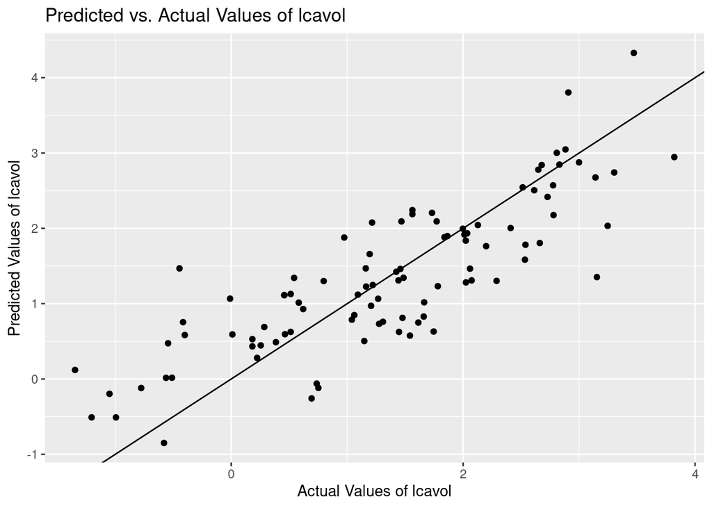

```r
ggplot(prostateCancer, aes(x=lcavol, y= predict(reg))) +
  geom_point() +
  geom_abline(intercept=0, slope=1) +
  labs(x='Actual Values of lcavol', y='Predicted Values of lcavol', title='Predicted vs. Actual Values of lcavol')
```

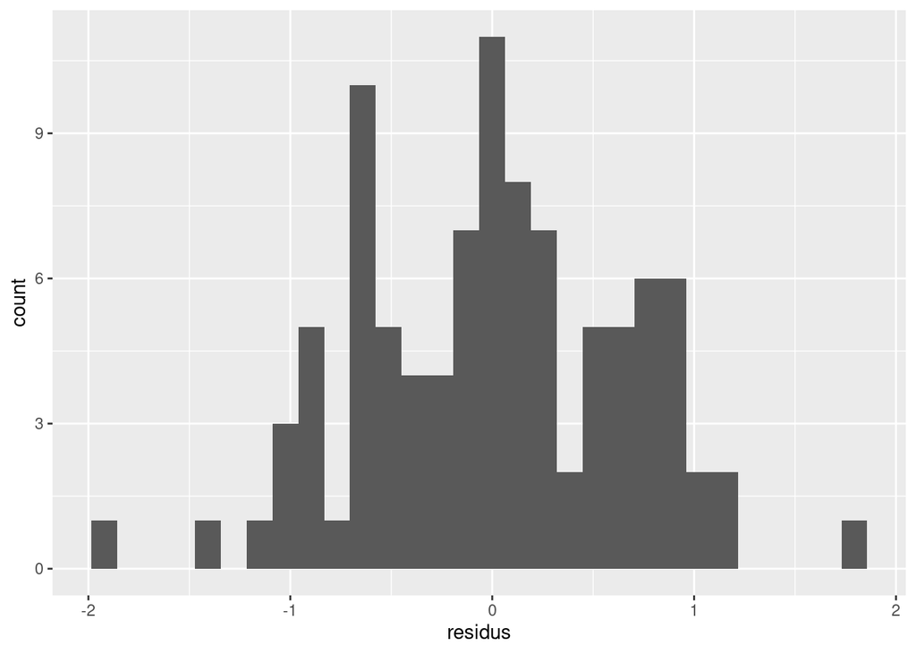

```r
residus <- residuals(reg)
residus_df <- data.frame(residus)
ggplot(residus_df, aes(x = residus)) + geom_histogram()
```

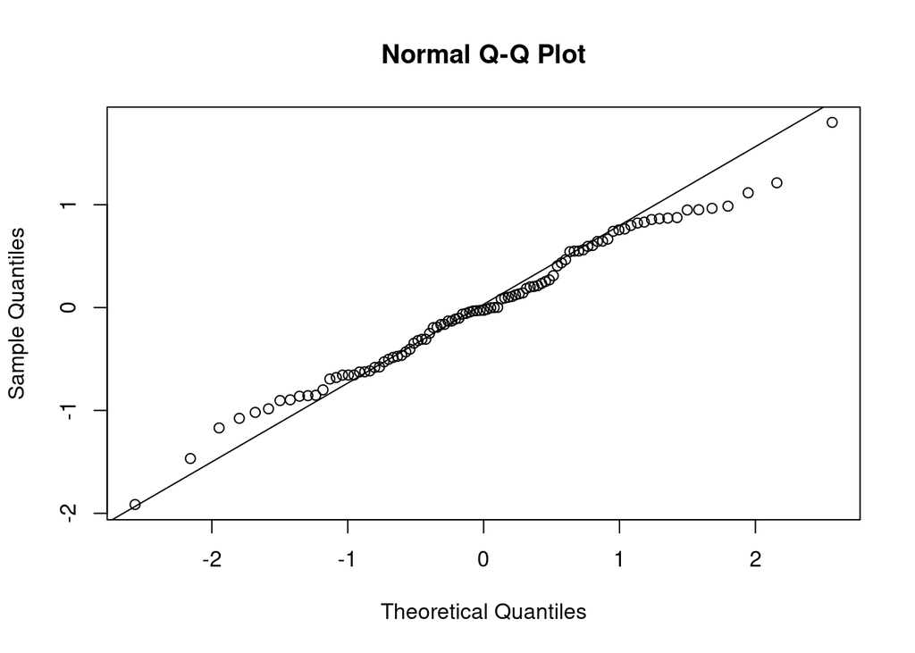

```r
#If the residuals are normally distributed, the points in the normal probability plot should fall along a straight line.
qqnorm(residus)
qqline(residus)
```

On peut remarquer à l’aide du graphe et de Shapiro que les résidus suivent une loi normale, car la p-value est de l’orde de 0.7 ce qui est largement supérieur à 0.05. Ainsi on peut assumer que les residus suivent une loi normale.

```r
shapiro.test(residus)
```

```
##
##  Shapiro-Wilk normality test
##
## data:  residus
## W = 0.99026, p-value = 0.705
```

Et calculant la somme des carrés des résidus, on trouve que le RSS est égal à $41.81$

```r
rss <- sum(resid(reg)^2)
```

## Question 7:

A priori, la valeur RSS indique à première vu un ajustement assez mauvais entre les valeurs prédites et les valeurs réelles du lcavol. Ceci est peut être dû au fait qu’il y a des prédicteurs qu’on peut enlever du modèle.

## Question 8:

On remarque qu’avec ce modèle le RSS associé devient plus important que le modèle précédent. Ceci est du certainement au fait qu’on a éliminé deux variables lpsa et lcp qui ont une forte corrélation avec lcavol, et qui pouvait nous aider à prédire de façon plus exact lcavol.

```r
reg2 <- lm(lcavol ~ . - lpsa - lcp, data = prostateCancer)
rss2 <- sum(resid(reg2)^2)
```

## Question 9:

```r
reg3 <- lm(lcavol ~ . - lweight, data = prostateCancer)
rss3 <- sum(resid(reg3)^2)
```

## Question 10:

```r
fit_gleason <- lm(lcavol ~ gleason, data = prostateCancer, x = TRUE)
#matrice de régression
X <- model.matrix(fit_gleason)
```

## Question 11:

```r
#On enlève l'intercepts
fit_gleason <- lm(lcavol ~ 0 + gleason, data = prostateCancer, x = TRUE)
X <- model.matrix(fit_gleason)
```

## Question 12:

```r
modele <- lm(lcavol ~ 0 + gleason, data = prostateCancer)
table_anova <- anova(modele)
print(table_anova)
```

```
## Analysis of Variance Table
##
## Response: lcavol
##           Df  Sum Sq Mean Sq F value    Pr(>F)
## gleason    4 211.263  52.816  49.674 < 2.2e-16 ***
## Residuals 93  98.881   1.063
## ---
## Signif. codes:  0 '***' 0.001 '**' 0.01 '*' 0.05 '.' 0.1 ' ' 1
```

```r
table_cmp <- model.tables(aov(modele))
modele <- lm(lcavol ~ 0 + gleason, data = prostateCancer)
```

Nous pouvons voir que la somme des carrés totale est de 310.144, ce qui représente la variation totale de lcavol. La variation expliquée par le Gleason est de 211.263, ce qui représente une grande proportion de la variation totale. La statistique F est de 49.674 et le p-value est très faible, ce qui indique que l’effet du Gleason est significatif. En outre, nous avons une différence significative entre les niveaux de Gleason, car la p-value est inférieure au seuil de significativité de 0,05. Enfin, nous pouvons voir que la somme des carrés résiduels est de 98.881, ce qui représente la variation non expliquée de lcavol.

## Question 13:

```r
# Effectuer l'ANOVA à deux facteurs
model2 <- aov(lcavol ~ svi*gleason, data= prostateCancer)
# Afficher les résultats de l'ANOVA
summary(model2)
```

```
##             Df Sum Sq Mean Sq F value   Pr(>F)
## svi          1  38.72   38.72  44.091 2.23e-09 ***
## gleason      3  13.69    4.56   5.198  0.00233 **
## svi:gleason  1   1.03    1.03   1.168  0.28270
## Residuals   91  79.92    0.88
## ---
## Signif. codes:  0 '***' 0.001 '**' 0.01 '*' 0.05 '.' 0.1 ' ' 1
```

## Question 14:

```r
model3 <- aov(lcavol ~ 0 + svi:gleason, data= prostateCancer)
summary(model3)
```

```
##             Df Sum Sq Mean Sq F value Pr(>F)
## svi:gleason  6 230.23   38.37   43.69 <2e-16 ***
## Residuals   91  79.92    0.88
## ---
## Signif. codes:  0 '***' 0.001 '**' 0.01 '*' 0.05 '.' 0.1 ' ' 1
```

## Question 15:

```r
model1 <- lm(lcavol ~ 1, data=prostateCancer)
model2 <- lm(lcavol ~ .,data = prostateCancer[,c(1,2,3)])
model3 <- lm(lcavol ~ .,data = prostateCancer[,c(1,2,5)])
res1 <- sum(resid(model1)^2)
res2 <- sum(resid(model2)^2)
res3 <- sum(resid(model3)^2)
```

## Question 16:

```r
x <- 1:8
y <- combn(x,2)
List_residuals <- list()
ColonneNames <- (colnames(prostateCancer))[-1]
rss_min <- 300
for (i in seq(1,length(y),2)){
  a <- prostateCancer[[ColonneNames[y[i]]]]
  b <- prostateCancer[[ColonneNames[y[i+1]]]]
  model <- lm(lcavol ~ a + b, data=prostateCancer)
  rss <- sum(resid(model)^2)
  if (rss < rss_min){
    rss_min = rss
    a_min <- ColonneNames[y[i]]
    b_min <- ColonneNames[y[i+1]]
  }
  List_residuals <- append(List_residuals,rss)
}
cat("The best predictors to use are:",a_min,b_min)
```

```
## The best predictors to use are: lcp lpsa
```

```r
cat("The error of this two predictors is:",rss_min)
```

```
## The error of this two predictors is: 47.2781
```

## Question 17:

```r
List_predicteur <- list()
List_residuals_all <- list()
meilleur_pred <- c()
for (k in seq(1:8)){
  x <- 2:9
  y <- combn(x,k)
  rss_min <- 5000
  for (i in 1:(length(y[1,]))){
    l <- y[,i]
    model <- lm(lcavol ~ ., data = prostateCancer[,c(1,l)])
    rss <- sum(resid(model)^2)
    if (rss < rss_min){
      rss_min <- rss
      predict_min <- colnames(prostateCancer[,c(1,l)])[-1]
      meilleur_pred <- l
    }
  }
  List_residuals_all <- append(List_residuals_all,rss_min)
  List_predicteur <- append(List_predicteur,list(meilleur_pred))
  cat("The best predictors to use for k = ",k ,"are:", predict_min,fill = TRUE, ", the error is:",rss_min)
}
```

```
## The best predictors to use for k =  1 are: lpsa , the error is: 61.42091
## The best predictors to use for k =  2 are: lcp lpsa , the error is: 47.2781
## The best predictors to use for k =  3 are: age lcp lpsa , the error is:
## 46.23783
## The best predictors to use for k =  4 are: age lbph lcp lpsa , the error is:
## 44.87841
## The best predictors to use for k =  5 are: age lcp gleason pgg45 lpsa
## , the error is: 43.68997
## The best predictors to use for k =  6 are: age lbph lcp gleason pgg45 lpsa
## , the error is: 42.17393
## The best predictors to use for k =  7 are: age lbph svi lcp gleason pgg45 lpsa
## , the error is: 41.81544
## The best predictors to use for k =  8 are: lweight age lbph svi lcp gleason
## pgg45 lpsa , the error is: 41.81407
```

## Question 18:

En effet, l’erreur de la somme des carrés des résidus n’est pas un bon indicateur si le choix du nombre des prédicteurs est bon. Car, plus on augmente le nombre de prédicteurs, on peut inclure des prédicteurs qui ne sont pas statistiquement significatif. Et aussi l’augmentation des prédicteurs génére une erreur moindre, mais ceci car il y a plus tôt un effet d’Overfit, mais pas une prédiction pure de la variable dépendante. Ainsi le modèle s’adapte assez bien avec les données d’apprentissage, mais il n’est pas si performant avec de nouveaux données. Ainsi l’un des concepts alternative pour déterminer la pertinence d’un modèle est la Split-Validation, car elle permet d’utiliser des mesures de performances sur les donnés d’apprentissage, mais aussi la capacité de se généraliser sur de nouveaux données.

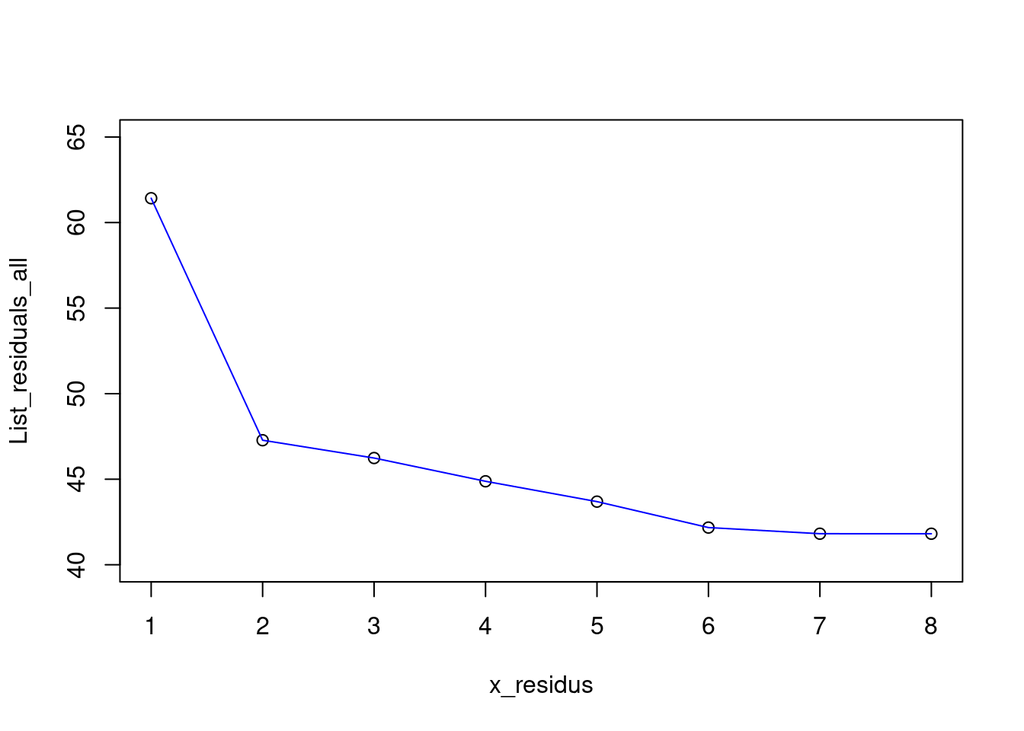

```r
x_residus <- 1:8
spline_fit <- smooth.spline(x_residus,List_residuals_all)
plot(x_residus,List_residuals_all,ylim = c(40,65))
lines(spline_fit, col="blue")
```

## Question 19:

La split-validation est une méthode d’évaluation des performances, elle consiste à les donnés d’entrainement en deux parties: un ensemble pour l’entrainement et un autre de validation. L’ensemble pour l’entrainement sert à ce qu’on a fait depuis tout à l’heure, l’entrainement de notre modèle, tandis que l’ensemble de validation est utilisé dans l’évaluation des performances sur des données qu’il n’a pas encore vue. Et ainsi, il nous permet de savoir si un overfit a eu lieu, dans le cas ou l’erreur sur l’ensemble des données d’entrainement est faible.

```r
validation_set <- 1:97 %% 3 == 0
```

## Question 20:

En effet, avec le paramètre subset qu’on a donné, l’adaptation du modèle s’effectue avec les données qui ne sont pas contenus dans la validation set. Et en calculant la MSE (Mean Squared Error), en considérant les prédicteurs lcp et lpsa, on trouve une erreur de l’ordre de $0.46$

```r
model <- lm(lcavol~., data=prostateCancer[,c(1,6,9)],subset=!validation_set)
predictNonValid<- predict(model,data.frame(prostateCancer[!validation_set,][-1]))
errorNonValid <- mean((prostateCancer[!validation_set,]$lcavol - predictNonValid)^2)
print(errorNonValid)
```

```
## [1] 0.4616663
```

## Question 21:

On remarque que l’erreur sur le Validation Set augmente, car notre modèle n’a pas pu s’entrainer sur cet ensemble de donnés. Ainsi cet erreur nous donne une idée sur les performances de notre modèle sur des données qu’il n’a jamais vu. On trouve dans ce cas, le Mean squared Error, est de l’ordre de $0.56$.

```r
predictValid <- predict(object = model, newdata = data.frame(prostateCancer[validation_set,][-1]))
errorValid <- mean((prostateCancer[validation_set,]$lcavol - predictValid)^2)
print(errorValid)
```

```
## [1] 0.5672302
```

## Question 22:

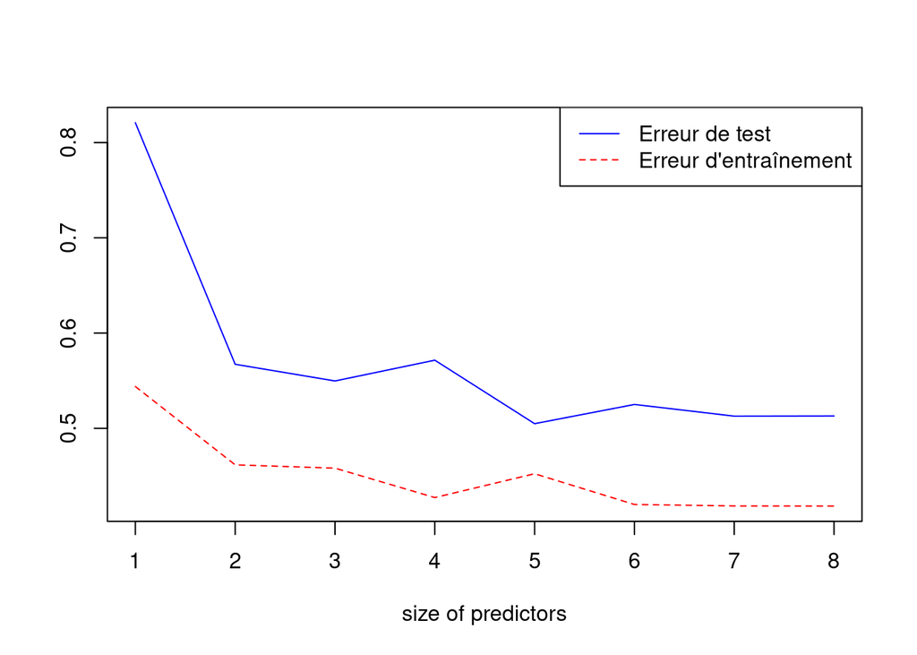

```r
# fonction pour trouver le meilleur modèle
best_model <- function(valid, list_train_error, list_pred_error) {
  # initialisation des listes pour stocker les erreurs d'entraînement et de prédiction
  list_train_error = list()
  list_pred_error = list()

  # boucle sur les 8 prédicteurs pour construire les modèles
  for (k in 1:8) {
    # ajustement du modèle sur les données d'entraînement, en utilisant les prédicteurs sélectionnés par List_predicteur[[k]]
    model <- lm(lcavol ~ . , data = prostateCancer[!valid, c(1, List_predicteur[[k]])])

    # prédiction sur les données d'entraînement et calcul de l'erreur
    lcavolPredictionN <- predict(object = model, newdata = data.frame(prostateCancer[!valid,][-1]))
    mean_tr_err = mean((prostateCancer[!valid,]$lcavol - lcavolPredictionN)**2)

    # stockage de l'erreur d'entraînement dans la liste
    list_train_error = append(list_train_error, mean_tr_err)

    # prédiction sur les données de validation et calcul de l'erreur
    lcavolPredictionN  <- predict(object = model, newdata = data.frame(prostateCancer[valid,][-1]))
    prediction_error <- mean((prostateCancer[valid,]$lcavol - lcavolPredictionN)**2)

    # stockage de l'erreur de prédiction dans la liste
    list_pred_error = append(list_pred_error, prediction_error)
  }

  # retourne un dictionnaire contenant l'indice du meilleur modèle et les listes d'erreurs
  return(list(optimal_value = which.min(list_pred_error), list_pred_error = list_pred_error, list_train_error = list_train_error))
}

# appel de la fonction best_model sur les données de validation
list_result <- best_model(validation_set, list_train_error, list_pred_error)

# récupération de l'indice du meilleur modèle
optimal_value <- list_result$optimal_value

# récupération des listes d'erreurs d'entraînement et de prédiction
list_train_error <- list_result$list_train_error
list_pred_error <- list_result$list_pred_error

# tracé des courbes d'erreurs en fonction de la taille des prédicteurs
matplot((1:8), cbind(list_pred_error, list_train_error), type = "l", col = c("blue","red"), xlab = "size of predictors", ylab = "", lty = 1:2)

# ajout d'une légende
legend("topright", legend = c("Erreur de test", "Erreur d'entraînement"), lty = 1:2, col = c("blue", "red"))
```

Et donc on déduit que les meilleurs prédicteurs sont :

```r
cat("Les meilleurs prédicteurs sont:",names(prostateCancer)[List_predicteur[[optimal_value]]],fill = TRUE)
```

```
## Les meilleurs prédicteurs sont: age lcp gleason pgg45 lpsa
```

## Question 23:

```r
validation_set_new <- 1:97 %% 3 == 2
validation_set_new[37] <- FALSE
cat("Les meilleurs prédicteurs sont:",names(prostateCancer)[List_predicteur[[best_model(validation_set_new,list_train_error,list_pred_error)$optimal_value]]],fill = TRUE)
```

```
## Les meilleurs prédicteurs sont: age lbph lcp lpsa
```

Et donc on remarque un changement de modèle par rapport à la question 22. Ainsi pour échapper à ce problème, on utilise la méthode de cross-validation qui nous permet de changer nos données d’entrainement et de validation.

```r
set.seed(42)
# Index de lignes aléatoires pour la sélection des données de test et de validation croisée
idx_random_rows = sample(1:97, replace = FALSE)

# Nombre d'observations pour les données de test et sélection croisée
n_test_obs = round(0.2 * 97)

# Variables prédictives et variable cible pour les données de test
X_test  = prostateCancer[idx_random_rows[1:n_test_obs], ][-1]
Y_test = prostateCancer[idx_random_rows[1:n_test_obs], ][1]

# Variables prédictives et variable cible pour la sélection croisée
X_cv = prostateCancer[c(idx_random_rows[(n_test_obs+1):97], 37), ][-1]
Y_cv = prostateCancer[c(idx_random_rows[(n_test_obs+1):97], 37), ][1]

# Nombre de plis pour la sélection croisée et nombre d'observations dans le pli de validation
n_folds = 5
n_cv_obs = length(Y_cv[, 1])

# Vecteur pour stocker les erreurs de validation croisée pour chaque modèle
cv_error_vec = c()

# Boucle pour ajuster différents modèles et calculer leurs erreurs de validation croisée
for (i in 1:8){
  cv_model_error_vec = c()
  for (fold in 1:n_folds){
    idx_val = setdiff(fold + seq(0, n_cv_obs - n_folds, by = n_folds), which(X_cv$gleason == 8))
    X_train = X_cv[-idx_val,]
    Y_train = Y_cv[-idx_val,]
    X_val = X_cv[idx_val,]
    Y_val = Y_cv[idx_val,]
    model = lm(Y_train ~ . , data = data.frame(cbind(Y_train, X_train[List_predicteur[[i]] - 1])))
    error = predict(object = model, newdata = data.frame(X_val)) - Y_val
    cv_model_error_vec = c(cv_model_error_vec, mean(error^2))
  }
  cv_error_vec = c(cv_error_vec, mean(cv_model_error_vec))
}

# Indice du modèle avec l'erreur de validation croisée minimale
best_model_idx = which.min(cv_error_vec)

# Modèle ajusté avec la sélection de variables optimale
best_model = lm(lcavol ~ . , data = data.frame(cbind(Y_cv, X_cv[List_predicteur[[which.min(cv_error_vec)]] - 1])))

# Prédiction de la variable cible pour les données de test avec le meilleur modèle
lcavol_predicted_test = predict(object = best_model, newdata = X_test)

# Erreur de prédiction pour les données de test avec le meilleur modèle
test_error = mean((Y_test[,] - lcavol_predicted_test)^2)

# Modèle ajusté avec la cinquième sélection de variables (pour comparaison)
best_model_1 = lm(lcavol ~ . , data = data.frame(cbind(Y_cv, X_cv[List_predicteur[[5]] - 1])))

# Prédiction de la variable cible pour les données de test avec le deuxième meilleur modèle
lcavol_predicted_test_1 = predict(object = best_model_1, newdata = X_test)

# Erreur de prédiction pour les données de test avec le deuxième meilleur modèle
test_error_1 = mean((Y_test[,] - lcavol_predicted_test_1)^2)
meilleur_taille <- which.min(cv_error_vec)
cat("La meilleur taille du modèle de prédiction est:",meilleur_taille)
```

```
## La meilleur taille du modèle de prédiction est: 6
```

## Question 24

```r
meilleur_modèle <- lm(lcavol ~ ., data = prostateCancer[,c(1,List_predicteur[[meilleur_taille]]-1)])
summary(meilleur_modèle)
```

```
##
## Call:
## lm(formula = lcavol ~ ., data = prostateCancer[, c(1, List_predicteur[[meilleur_taille]] -
##     1)])
##
## Residuals:
##      Min       1Q   Median       3Q      Max
## -1.85123 -0.50418 -0.01888  0.40247  2.48434
##
## Coefficients:
##              Estimate Std. Error t value Pr(>|t|)
## (Intercept) -1.057760   0.905061  -1.169   0.2457
## lweight      0.374413   0.215288   1.739   0.0855 .
## age          0.013924   0.012966   1.074   0.2858
## svi1         0.331562   0.284848   1.164   0.2476
## lcp          0.478036   0.100285   4.767 7.35e-06 ***
## gleason7     0.623289   0.247201   2.521   0.0135 *
## gleason8    -0.552265   0.900818  -0.613   0.5414
## gleason9     1.081710   0.577411   1.873   0.0643 .
## pgg45       -0.009686   0.005410  -1.790   0.0768 .
## ---
## Signif. codes:  0 '***' 0.001 '**' 0.01 '*' 0.05 '.' 0.1 ' ' 1
##
## Residual standard error: 0.831 on 88 degrees of freedom
## Multiple R-squared:  0.5443, Adjusted R-squared:  0.5029
## F-statistic: 13.14 on 8 and 88 DF,  p-value: 2.644e-12
```

Le choix du meilleur modèle dépend de la méthode de division des données. Dans la fonction précédente, nous avons fixé un nombre de graine pour avoir les mêmes résultats. La validation croisée K-fold semble être la meilleure méthode pour choisir le meilleur modèle de prédiction de lcoval.